# Publication ready figures with biogrowth

# Introduction

The **biogrowth** package for R allows for modelling of microbial growth using predictive microbiology. This vignette is an addition to the main vignette of the package, giving further detail on how tu use the functions in **biogrowth** to prepare publication ready figures. Here, we assume the reader is already familiar with **biogrowth**.

```r
library(biogrowth)
library(tidyverse)
```

Several functions in the package make use of stochastic algorithms. For reproducibility, we will set the seed of R’s internal pseodu-random number generator (PRNG) to some arbitrary value

```r
set.seed(1241)
```

**Biogrowth** uses the **cowplot** package and the **cowplot** theme as default. Therefore, the vanilla figures produced by **biogrowth** already have a nice clean theme and could be used in a publication as is. However, more control over formatting options can be needed in order to standardize plots or when preparing figures for a specific journal.

**Cowplot** is a package that works with **gplot2**, and therefore the plots can be manipulated in the same way. Arguments that control the way that data is represented by geoms such as:

- `colour`
- `size`
- `linetype`

would normally go inside the ggplot call. In **biogrowth**, a modified version of these arguments can be set by providing additional arguments to plotting methods in **biogrowth**.

We start with a prediction using the modified Gompertz model

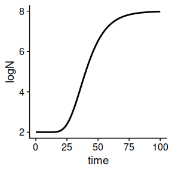

```r
# Specify the model
my_model <- "modGompertz"

# Define the starting parameters (`mu`, `lambda` and `C`), and the initial count in a list
my_pars <- list(logN0 = 2, C = 6, mu = .2, lambda = 25)

# Define the storage times
my_time <- seq(0, 100, length = 1000)

# Call to predict_isothermal_growth using the arguments defined above
static_prediction <- predict_isothermal_growth(my_model, my_time, my_pars)

# Plotting
plot(static_prediction)
```

By setting the optional arguments `line_size`, `line_col`, and `line_size` to `plot()`, we can control the size, colour, and linetype of the plot.

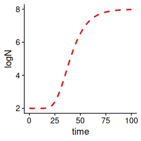

```r
# Plotting
plot(static_prediction,
     line_col = "red", # also takes strings or hexadecimal code, try entering "#56B4E9" for blue
     line_size = 1,
     line_type  = "dashed")
```

## Dynamic growth plotting

The same attributes can be set via the `plot()` function for the primary axis of `dynamic_prediction()`

```r
# Example data from the main vignette
my_conditions <- tibble(time = c(0, 5, 40),
                         temperature = c(20, 30, 35),
                         pH = c(7, 6.5, 5)
                         )
my_primary <- list(mu_opt = 2,
             Nmax = 1e8,
             N0 = 1e0,
             Q0 = 1e-3)

sec_temperature <- list(model = "Zwietering",
                        xmin = 25,
                        xopt = 35,
                        n = 1)

sec_pH = list(model = "CPM",
              xmin = 5.5,
              xopt = 6.5,
              xmax = 7.5,
              n = 2)

my_secondary <- list(
    temperature = sec_temperature,
    pH = sec_pH
    )

my_times <- seq(0, 50, length = 1000)

# Calling the function
dynamic_prediction <- predict_dynamic_growth(my_times,
                       my_conditions, my_primary,
                       my_secondary)
```

The line of the predicted values can be modified via additional arguments to `plot()`

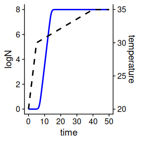

```r
plot(dynamic_prediction,
     add_factor = "temperature",
     line_col = "blue")
```

## Plotting of fits

```r
# Example data from the main vignette
my_data <- tibble(time = c(0, 25, 50, 75, 100),
                  logN = c(2, 2.5, 7, 8, 8))
my_model <- "Baranyi"
known <- c()
start = c(logNmax = 8, lambda = 25, logN0 = 2, mu = .2)

# Fitting
static_fit <- fit_isothermal_growth(my_data, my_model,
                      start, known
                      )
```

and plot this with additional arguments for the color of the points, and a different `line_type`

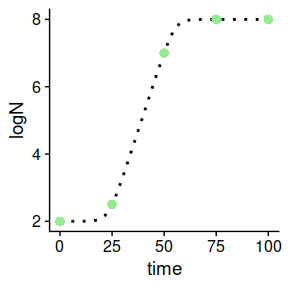

```r
# Plotting
plot(static_fit,
     point_col = "lightgreen",
     point_size = 3,
     line_type = 3)
```

```r
# Example data from the main vignette

my_model <- "Baranyi"
my_times <- seq(0, 30, length = 100)
n_sims <- 100  # Just as an example, should be increased in actual analyses

pars <- tribble(
    ~par, ~mean, ~sd, ~scale,
    "logN0", 0, .2, "original",
    "mu", 2, .3, "sqrt",
    "lambda", 4, .4, "sqrt",
    "logNmax", 6, .5, "original"
)

stoc_growth <- predict_stochastic_growth(my_model, my_times, n_sims, pars)
```

We can supply `plot()` with the arguments that control the size, type and colour of the q50 line, and in addition:

- `ribbon80_fill`: the colour of the ribbon denoting the space between the 10th and 90th quantile
- `ribbon90_fill`: the colour of the ribbon denoting the space between the 5th and 95th quantile
- `alpha80`: the opacity of the ribbon80_fill
- `alpha90`: the opacity of the ribbon90_fill

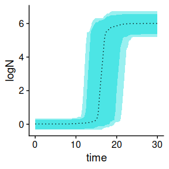

```r
plot(stoc_growth,
     line_type = 3,
     ribbon80_fill = "#00dbdb",
     ribbon90_fill = "#00dbdb",
     alpha80 = .5,
     alpha90 = .4)
```

Note that `ribbon80_fill` and `ribbon90_fill` can be set to different colours, but this is not always an improvement

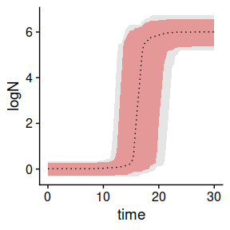

```r
plot(stoc_growth,
     line_type = 3,
     ribbon80_fill = "red",
     ribbon90_fill = "grey",
     alpha80 = .5,
     alpha90 = .4)
```

## Distributions of times to reach a certain count

We use the result of `predict_stochastic_growth()` stored in `stoc_growth` from the example above.

```r
time_distrib <- distribution_to_logcount(stoc_growth, 4)
```

The prediction of times to reach a specified count is shown in a histogram. We can adjust the binwidth of the histogram by setting the `bin_width` argument. In this example values between 1 and 3 would be representative.

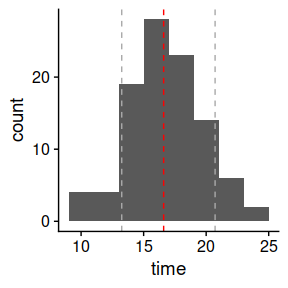

```r
plot(time_distrib, bin_width = 2)
```

## Combining plots into subplots

The function `plot_grid()` of **cowplot** can be used to combine different plots into a grid.

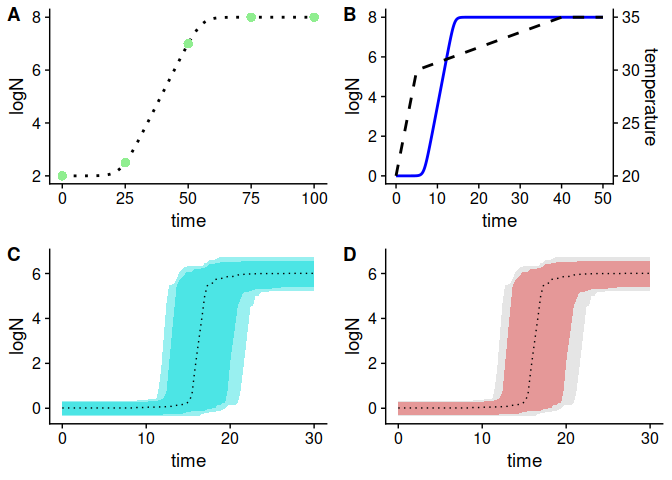

```r
library(cowplot)

p1 <- plot(static_fit,
     point_col = "lightgreen",
     point_size = 3,
     line_type = 3)

p2 <- plot(dynamic_prediction,
     add_factor = "temperature",
     line_col = "blue")

p3 <- plot(stoc_growth,
     line_type = 3,
     ribbon80_fill = "#00dbdb",
     ribbon90_fill = "#00dbdb",
     alpha80 = .5,
     alpha90 = .4)

p4 <- plot(stoc_growth,
     line_type = 3,
     ribbon80_fill = "red",
     ribbon90_fill = "grey",
     alpha80 = .5,
     alpha90 = .4)

# Making a nice grid of plots
plot_grid(p1, p2, p3, p4, labels = "AUTO")
```

# Additional changes to the plotting area

Properties of the plotting area are controlled by ggplot2 via additional layers. We can do the same here, with additional layers to the `plot()` function. For instance, to change the thickness of the x- and y-axis we use a theme layer adressing `axis.line` to change its colour and size.

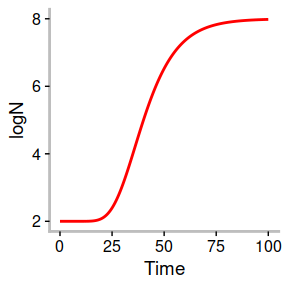

```r
# Axis line thickness via theme()
plot(static_prediction, line_col = "red") +
  theme(axis.line = element_line(colour = 'grey', size = 1)) + # Adjust size and colour to taste
  xlab("Time")
```

In some cases, the automatic scaling that ggplot2 uses might not be optimal. We can use the coord_cartesian() function to change the limits of the x- and y-axis

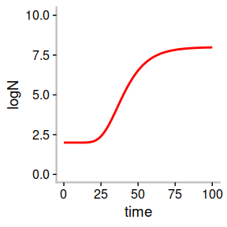

```r
# From the previous example
plot(static_prediction, line_col = "red") +
  theme(axis.line = element_line(colour = 'grey', size = 0.8)) + # Adjust size and colour to taste
  coord_cartesian(xlim = c(0, 100), ylim = c(0, 10)) # changing the axis limits
```

## Saving and reshaping plots

`ggsave()` will automatically save the last plot to a specified location. It needs a filename as a string, for instance “static_prediction.pdf” to save the figure as a pdf. It also needs a location to save to (defaults to the working directory), and optionally the user can set dimentions and units.

```r
# We save the plot as p1, notice that it does not get drawn now
p1 <- plot(static_prediction, line_col = "red") +
  theme(axis.line = element_line(colour = 'grey', size = 0.8))

# We save P1 as .pdf, as a 20x 20 cm square
# ggsave("static_prediction.pdf", p1, width = 20, height = 20, units = "cm")
```

# Full manual control

By accessing the data directly, the experienced user can get full control over plotting:

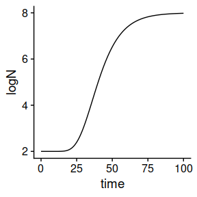

```r
# Vanilla biogrowth figure
static_prediction$simulation %>%
  ggplot(., aes(x= time, y =logN )) +
  geom_line() +
  theme_cowplot()
```

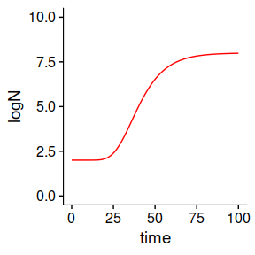

```r
# Directly accessing the simulation data from static_prediction
P <- ggplot(static_prediction$simulation, aes(x= .data$time, y =.data$logN)) +
  geom_line(color="red") +
  theme_cowplot()

P +
  coord_cartesian(xlim = c(0, 100), ylim = c(0, 10)) +
  theme(axis.line = element_line(colour = 'black', size = 0.4))
```

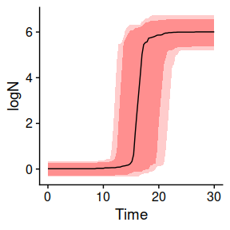

```r
# Plotting
ggplot(stoc_growth$quantiles, aes(x = .data$time)) +
        geom_ribbon(aes(ymin = .data$q10, ymax = .data$q90), fill = "red",  alpha = .3) +
        geom_ribbon(aes(ymin = .data$q05, ymax = .data$q95), fill = "red",  alpha = .2) +
        geom_line(aes(y = .data$q50)) +
        xlab("Time") +
        ylab("logN") +
        cowplot::theme_cowplot()
```

## Comparing predictions

In order to compare the outcome of simulations with different parameters we can combine simulations into a single plot using the `plot_grid()` function from **cowplot**.

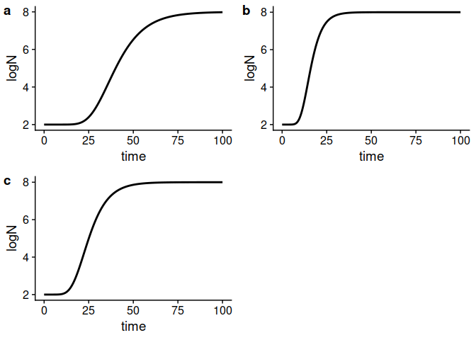

```r
# Plotting multiple plots together
my_model <- "modGompertz"

my_pars <- list(logN0 = 2, C = 6, mu = .2, lambda = 25)
my_time <- seq(0, 100, length = 1000)
static_prediction1 <- predict_isothermal_growth(my_model, my_time, my_pars)
p1 <- plot(static_prediction1)

my_pars <- list(logN0 = 2, C = 6, mu = .5, lambda = 10)
my_time <- seq(0, 100, length = 1000)
static_prediction2 <- predict_isothermal_growth(my_model, my_time, my_pars)
p2 <- plot(static_prediction2)

my_pars <- list(logN0 = 2, C = 6, mu = .3, lambda = 15)
my_time <- seq(0, 100, length = 1000)
static_prediction3 <- predict_isothermal_growth(my_model, my_time, my_pars)
p3 <- plot(static_prediction3)


# Plotting using the cowplot plot_grid function
plot_grid(p1, p2, p3, labels = "auto")
```

Alternatively, one can combine the predicted counts into a single tibble and, then, plot all the growth curves in a single plot.

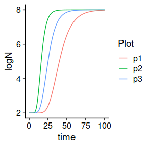

```r
bind_rows(
  tibble(Plot = rep("p1", 1000), time = static_prediction1$simulation$time, logN = static_prediction1$simulation$logN),
  tibble(Plot = rep("p2", 1000), time = static_prediction2$simulation$time, logN = static_prediction2$simulation$logN),
  tibble(Plot = rep("p3", 1000), time = static_prediction3$simulation$time, logN = static_prediction3$simulation$logN)) %>%
  ggplot(., aes(x = .data$time, y = .data$logN, col = .data$Plot)) +
  geom_line() +
  theme_cowplot()
```